# Notebook 04 – Solutions

## Getting Started

Before running this notebook, select “Session > Restart R and Clear Output” in the menu above to start a new R session. This will clear any old data sets and give us a blank slate to start with.

After starting a new session, run the following code chunk to load the libraries and data that we will be working with today.

I have set the options `include=FALSE` and `message=FALSE` to avoid cluttering the solutions with all the output from this code.

## Organizing Data

### Verbs

In these notes we are going to cover a set of functions that take a data frame as an input and return a new version of the data frame. These functions are called *verbs* and come from the **dplyr** package. If you are familiar with running database queries, note that all of these verbs map onto SQL commands. In fact, R can be set up so that **dplyr** is called over a database rather than a local data frame in memory.

There are over 40 verbs in the **dplyr** package, though most are a minor variant or specific application of another verb. In this notebook we will see only four of them, all of which are related to selecting and arranging rows and columns:

- select a subset of rows from the original data set (`filter` and `slice`)
- select a subset of columns from the original data set (`select`)
- sort the rows of a data set (`arrange`)

In all verb functions, the first argument is the original data frame and the output is a new data frame. Here, we will also see the functions `between` and `%in%` to assist with the filtering command and `desc` to assist with arranging the rows of a data set.

Note that **verbs do not modify the original data**; they operate on a copy of the original data. We have to make an explicit name for the new data set if we want to save it for use elsewhere.

## Choosing rows

It is often useful to take a subset of the rows of an existing data set, for example if you want to build a model on a certain subpopulation or highlight a particular part of the data in a plot. Perhaps the most straightforward way to take a subset of rows is to indicate the specific row numbers that we want to extract. In order to select rows by row numbers, we use the verb `slice`, followed by the numbers of the rows we want separated by commas. Here is an example taking the second, fifth, and seventh rows of the data:

```r
food %>%
  slice(2, 5, 7)
```

```
## # A tibble: 3 x 17
##   item  food_group calories total_fat sat_fat cholesterol sodium carbs fiber
##   <chr> <chr>         <dbl>     <dbl>   <dbl>       <dbl>  <dbl> <dbl> <dbl>
## 1 Aspa… vegetable        20       0.1   0.046           0      2  3.88   2.1
## 2 Chic… grains          180       2.9   0.309           0    243 30.0    8.6
## 3 Beef  meat            288      19.5   7.73           87    384  0      0
## # … with 8 more variables: sugar <dbl>, protein <dbl>, iron <dbl>,
## #   vitamin_a <dbl>, vitamin_c <dbl>, wiki <chr>, description <chr>,
## #   color <chr>
```

As mentioned above, the code here does not change the data set `food` itself. It still has all 61 rows of food contained in it. If we want to create a new data set with just these three food item, we need to explicitly name and assign it. For example, here is how we would create a data set of the first five food items named `food_first_five`:

```r
food_first_five <- food %>%
  slice(1, 2, 3, 4, 5)
```

There is a convenient a shorthand for selecting a range of row numbers, for example every row from the tenth to the twentieth, by indicating the starting and ending row number by a colon. Here, for example, is another way to select the first five rows of the data set:

```r
food %>%
  slice(1:5)
```

```
## # A tibble: 5 x 17
##   item  food_group calories total_fat sat_fat cholesterol sodium carbs fiber
##   <chr> <chr>         <dbl>     <dbl>   <dbl>       <dbl>  <dbl> <dbl> <dbl>
## 1 Apple fruit            52       0.1   0.028           0      1 13.8    2.4
## 2 Aspa… vegetable        20       0.1   0.046           0      2  3.88   2.1
## 3 Avoc… fruit           160      14.6   2.13            0      7  8.53   6.7
## 4 Bana… fruit            89       0.3   0.112           0      1 22.8    2.6
## 5 Chic… grains          180       2.9   0.309           0    243 30.0    8.6
## # … with 8 more variables: sugar <dbl>, protein <dbl>, iron <dbl>,
## #   vitamin_a <dbl>, vitamin_c <dbl>, wiki <chr>, description <chr>,
## #   color <chr>
```

Another way to take a subset of our data is to select rows based on conditions about the variables in the data set. To do this we use the `filter` function, which accepts a statement about variable in the data set. Only rows where the statements are true will be returned. For example, here is how we use the `filter` command to select the foods that have more than 150 calories grams of sugar in each serving:

```r
food %>%
  filter(calories > 150)
```

```
## # A tibble: 20 x 17
##    item  food_group calories total_fat sat_fat cholesterol sodium carbs fiber
##    <chr> <chr>         <dbl>     <dbl>   <dbl>       <dbl>  <dbl> <dbl> <dbl>
##  1 Avoc… fruit           160      14.6   2.13            0      7  8.53   6.7
##  2 Chic… grains          180       2.9   0.309           0    243 30.0    8.6
##  3 Beef  meat            288      19.5   7.73           87    384  0      0
##  4 Catf… fish            240      14.5   3.25           69    398  8.54   0.5
##  5 Chee… dairy           350      26.9  16.6            83    955  4.71   0
##  6 Chic… meat            237      13.4   3.76           87    404  0      0
##  7 Clam  fish            180       8     1.60           56    400 11.1    0.5
##  8 Cod   fish            211      10.8   2.22           57    401  8.25   0.5
##  9 Hali… fish            239      17.7   3.10           59    103  0      0
## 10 Lamb  meat            292      20.7   8.76           96    394  0      0
## 11 Oat   grains          389       6     1.22            0      2 66.3   10.6
## 12 Oyst… fish            160       7.9   1.85           57    595 12.5    0.5
## 13 Penne grains          157       0.9   0.175           0    233 30.7    1.8
## 14 Pork  meat            271      17     6.17           90    384  0      0
## 15 Salm… fish            171       7.5   1.31           62    467  0.49   0
## 16 Scal… fish            217      10.9   2.22           54    487 10.5    0.5
## 17 Sour… dairy           214      20.9  13.0            44     53  4.27   0
## 18 Swor… fish            177       8.2   1.96           47    494  0.49   0
## 19 Tuna  fish            153       3.9   0.811          53    366  0.41   0
## 20 Turk… meat            187       7     2.00           77     69  0      0
## # … with 8 more variables: sugar <dbl>, protein <dbl>, iron <dbl>,
## #   vitamin_a <dbl>, vitamin_c <dbl>, wiki <chr>, description <chr>,
## #   color <chr>
```

```r
food %>%
  filter(between(total_fat, 2, 3))
```

```
## # A tibble: 4 x 17
##   item  food_group calories total_fat sat_fat cholesterol sodium carbs fiber
##   <chr> <chr>         <dbl>     <dbl>   <dbl>       <dbl>  <dbl> <dbl> <dbl>
## 1 Chic… grains          180       2.9   0.309           0    243 30.0    8.6
## 2 Quin… grains          143       2.2   0.226           0    196 26.4    2.3
## 3 Shri… fish            144       2.3   0.446         206    613  1.24   0
## 4 Pota… vegetable       104       2     0.458           0    254 19.4    1.7
## # … with 8 more variables: sugar <dbl>, protein <dbl>, iron <dbl>,
## #   vitamin_a <dbl>, vitamin_c <dbl>, wiki <chr>, description <chr>,
## #   color <chr>
```

If you want to filter on a categorical variable, you can use the `%in%` operator to select specific categories. Here is the code to filter only the fish and vegetable variables:

```r
food %>%
  filter(food_group %in% c("fish", "vegetable"))
```

```
## # A tibble: 30 x 17
##    item  food_group calories total_fat sat_fat cholesterol sodium carbs fiber
##    <chr> <chr>         <dbl>     <dbl>   <dbl>       <dbl>  <dbl> <dbl> <dbl>
##  1 Aspa… vegetable        20       0.1   0.046           0      2  3.88   2.1
##  2 Stri… vegetable        31       0.1   0.026           0      6  7.13   3.4
##  3 Bell… vegetable        26       0     0.059           0      2  6.03   2
##  4 Crab  fish             87       1     0.222          78    293  0.04   0
##  5 Broc… vegetable        34       0.3   0.039           0     33  6.64   2.6
##  6 Cabb… vegetable        24       0.1   0.016           0     18  5.58   2.3
##  7 Carr… vegetable        41       0.2   0.037           0     69  9.58   2.8
##  8 Catf… fish            240      14.5   3.25           69    398  8.54   0.5
##  9 Caul… vegetable        25       0     0.032           0     30  5.3    2.5
## 10 Cele… vegetable        14       0.1   0.043           0     80  2.97   1.6
## # … with 20 more rows, and 8 more variables: sugar <dbl>, protein <dbl>,
## #   iron <dbl>, vitamin_a <dbl>, vitamin_c <dbl>, wiki <chr>,
## #   description <chr>, color <chr>
```

As with the other verbs, we can chain together multiple calls to produce more complex logic. For example, this code selects fruits that have more than 150 calories per serving:

```r
food %>%
  filter(calories > 150) %>%
  filter(food_group %in% c("fruit"))
```

```
## # A tibble: 1 x 17
##   item  food_group calories total_fat sat_fat cholesterol sodium carbs fiber
##   <chr> <chr>         <dbl>     <dbl>   <dbl>       <dbl>  <dbl> <dbl> <dbl>
## 1 Avoc… fruit           160      14.6    2.13           0      7  8.53   6.7
## # … with 8 more variables: sugar <dbl>, protein <dbl>, iron <dbl>,
## #   vitamin_a <dbl>, vitamin_c <dbl>, wiki <chr>, description <chr>,
## #   color <chr>
```

Which results in a reduced data set with only 1 row (avocados). You can also use `==` to test equality (`food_group == "fruit"`) or `!=` to test whether a variable is *not* equal to a specific value.

It is also possible to create a chain of calls that then get piped into a call to the `ggplot` function. For example, here is a plot of the fruits and vegetables with the Avocado outlier removed (by limiting the maximum available total fat).

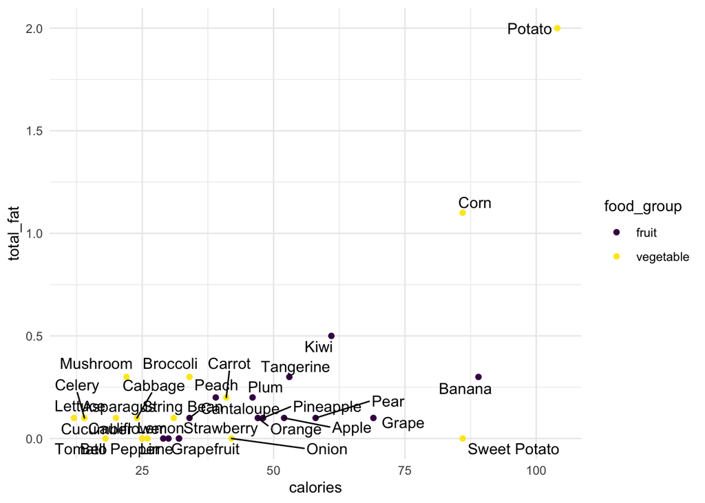

```r
food %>%
  filter(food_group %in% c("vegetable", "fruit")) %>%
  filter(total_fat < 10) %>%
  ggplot() +
    geom_point(aes(x = calories, y = total_fat, color = food_group)) +
    geom_text_repel(aes(x = calories, y = total_fat, label = item)) +
    scale_color_viridis_d()
```

The pattern of a starting with a data set, applying a number of transformations, and then creating a visualization of the data will become a common pattern in our analyses.

## Data and Layers

Now that we know how to create a subset of our data, let’s use this new knowledge to build some interesting data visualizations. To start, create a data set that just consists of the food types that are in the meat food group:

```r
food_meat <- filter(food, food_group %in% c("meat"))
food_meat
```

```
## # A tibble: 6 x 17
##   item  food_group calories total_fat sat_fat cholesterol sodium carbs fiber
##   <chr> <chr>         <dbl>     <dbl>   <dbl>       <dbl>  <dbl> <dbl> <dbl>
## 1 Beef  meat            288      19.5    7.73          87    384     0     0
## 2 Chic… meat            237      13.4    3.76          87    404     0     0
## 3 Duck  meat            132       5.9    2.32          77     74     0     0
## 4 Lamb  meat            292      20.7    8.76          96    394     0     0
## 5 Pork  meat            271      17      6.17          90    384     0     0
## 6 Turk… meat            187       7      2.00          77     69     0     0
## # … with 8 more variables: sugar <dbl>, protein <dbl>, iron <dbl>,
## #   vitamin_a <dbl>, vitamin_c <dbl>, wiki <chr>, description <chr>,
## #   color <chr>
```

One of the core ideas behind the Grammar of Graphics is that complex visualizations can be constructed by layering relatively simply elements on top of one another. What if we wanted to put together two layers where one layer uses the `food` data set and the other uses `food_meat`? To do this, we can *override* the default data set in a layer with the option `data =`. This will use a different data set within a particular layer. For example, here is how we can layer the meat data set on top of the rest of the food items.

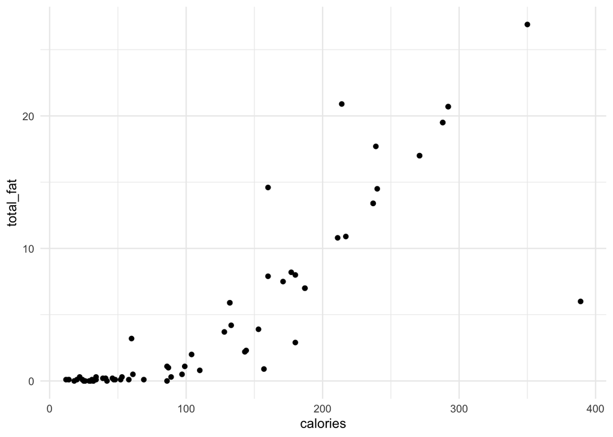

```r
food %>%
  ggplot() +
    geom_point(aes(x = calories, y = total_fat)) +
    geom_point(aes(x = calories, y = total_fat), data = food_meat)
```

This plot, however, does not look any different than it would if we were just to plot all of the food together. The second layer of points just sits unassumingly on top of the rest of the data. To rectify this, we can color each layer a different color in order to distinguish them from one another. Let’s try to highlight the meat food group in a navy blue, while making the rest of the points a light grey:

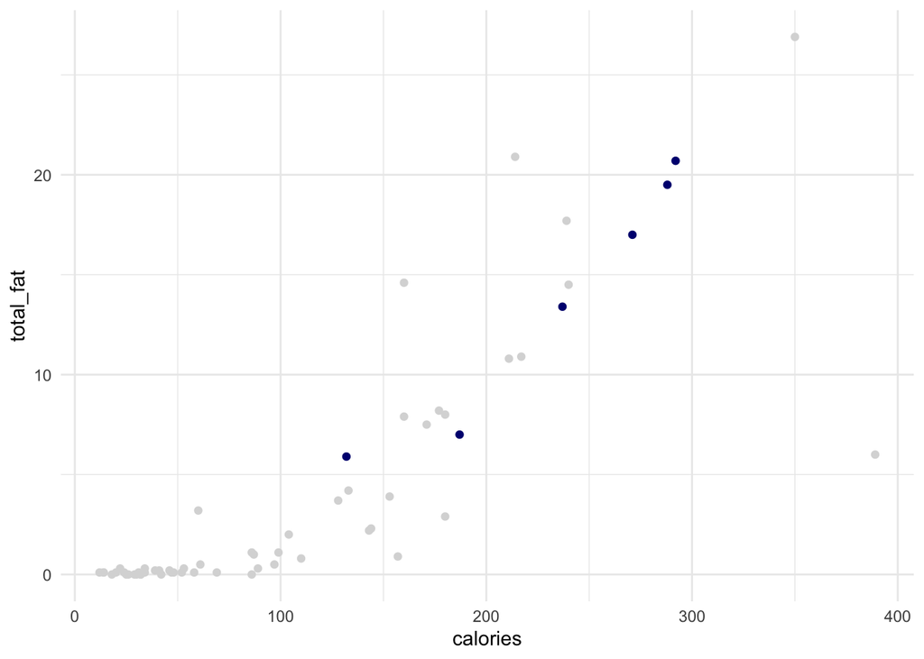

```r
food %>%
  ggplot() +
    geom_point(aes(x = calories, y = total_fat), color = "grey85") +
    geom_point(aes(x = calories, y = total_fat), color = "navy", data = food_meat)
```

We now have a plot that shows exactly where the meats are relative to the other food items. We can further build up the plot by showing the names of just these rows of the dataset as well:

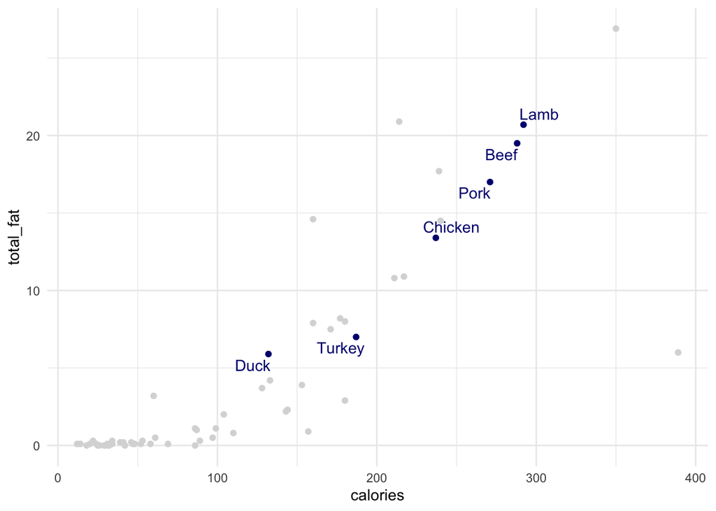

```r
food %>%
  ggplot() +
    geom_point(aes(x = calories, y = total_fat), color = "grey85") +
    geom_point(aes(x = calories, y = total_fat), color = "navy", data = food_meat) +
    geom_text_repel(
      aes(x = calories, y = total_fat, label = item),
      color = "navy",
      data = food_meat
    )
```

Notice that the code is starting to get a bit more complicated and some of the graphic layers are becoming a bit long. This is a good place to use the shorthand notation to inherit aesthetics across layers, like this:

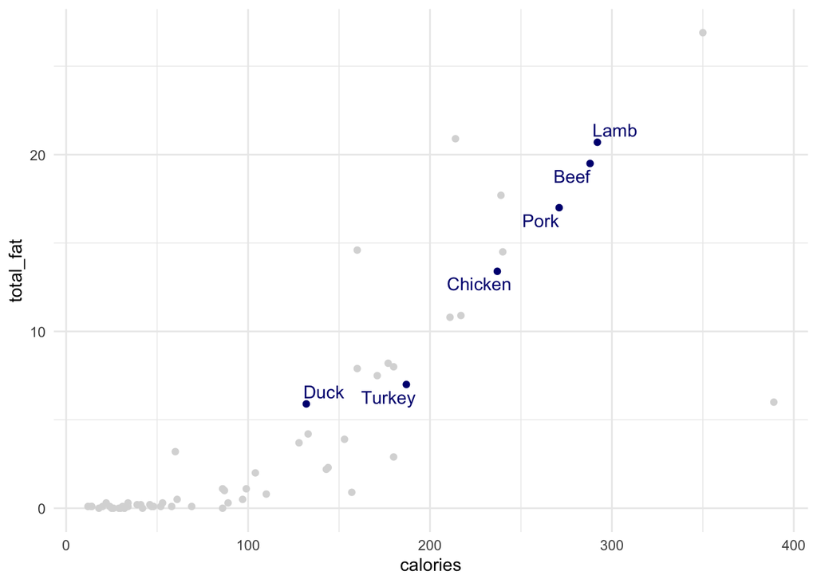

```r
food %>%
  ggplot(aes(calories, total_fat)) +
    geom_point(color = "grey85") +
    geom_point(color = "navy", data = food_meat) +
    geom_text_repel(aes(label = item), color = "navy", data = food_meat)
```

Notice how a relatively small set of commands can be put together in different ways to build a variety of plots. Already, we are making further progress towards building informative and beautiful graphics in R!

## Selecting Columns

It is also possible to take a subset of the columns in a data set. To do this, we make use of the verb `select`. We pass it the names of the variables we want to keep in the output data set, in the (possibly new) order that we want the columns to be arranged in. Here, for example, is a new version of the foods data set containing only the food item name followed by the amount of Vitamin A and Vitamin C:

```r
food %>%
  select(item, vitamin_a, vitamin_c)
```

```
## # A tibble: 61 x 3
##    item        vitamin_a vitamin_c
##    <chr>           <dbl>     <dbl>
##  1 Apple               1         8
##  2 Asparagus          15         9
##  3 Avocado             3        17
##  4 Banana              1        15
##  5 Chickpea            0         3
##  6 String Bean        14        27
##  7 Beef                0         0
##  8 Bell Pepper        63       317
##  9 Crab                0         5
## 10 Broccoli           12       149
## # … with 51 more rows
```

## Arranging Rows

The verbs `slice` and `filter` determine a subset of rows to keep from the original data set. The `arrange` verb, in contrast, keeps all of the original data but re-orders its rows. Specifically, we give it one or more variable names and it sorts the data by the first variable from smallest to largest (or alphabetically for character variables). In the case of ties, the second variable is used if given. More variables can be given to further break additional ties. Here is an example where we order the data set first by `food_group` and then by `calories`:

```r
food %>%
  arrange(food_group, calories)
```

```
## # A tibble: 61 x 17
##    item  food_group calories total_fat sat_fat cholesterol sodium carbs fiber
##    <chr> <chr>         <dbl>     <dbl>   <dbl>       <dbl>  <dbl> <dbl> <dbl>
##  1 Milk  dairy            60       3.2   1.86           10     40  4.52   0
##  2 Yogu… dairy            99       1.1   0.742           5     53 18.6    0
##  3 Sour… dairy           214      20.9  13.0            44     53  4.27   0
##  4 Chee… dairy           350      26.9  16.6            83    955  4.71   0
##  5 Crab  fish             87       1     0.222          78    293  0.04   0
##  6 Lobs… fish             97       0.5   0.106          71    700  1.27   0
##  7 Hadd… fish            128       3.7   0.69           66    402  0.48   0.1
##  8 Flou… fish            133       4.2   0.867          56    417  0.41   0
##  9 Shri… fish            144       2.3   0.446         206    613  1.24   0
## 10 Tuna  fish            153       3.9   0.811          53    366  0.41   0
## # … with 51 more rows, and 8 more variables: sugar <dbl>, protein <dbl>,
## #   iron <dbl>, vitamin_a <dbl>, vitamin_c <dbl>, wiki <chr>,
## #   description <chr>, color <chr>
```

In the new data set all of the dairy products come up first followed by the fish products. Within each group, the items are sorted from the lowest to highest number of calories.

The ordering can be reversed (i.e., from the highest to the lowest value) be wrapping a variable in the function `desc()`, such as this ordering from the most saturated fat to the least:

```r
food %>%
  arrange(desc(sat_fat))
```

```
## # A tibble: 61 x 17
##    item  food_group calories total_fat sat_fat cholesterol sodium carbs fiber
##    <chr> <chr>         <dbl>     <dbl>   <dbl>       <dbl>  <dbl> <dbl> <dbl>
##  1 Chee… dairy           350      26.9   16.6           83    955  4.71   0
##  2 Sour… dairy           214      20.9   13.0           44     53  4.27   0
##  3 Lamb  meat            292      20.7    8.76          96    394  0      0
##  4 Beef  meat            288      19.5    7.73          87    384  0      0
##  5 Pork  meat            271      17      6.17          90    384  0      0
##  6 Chic… meat            237      13.4    3.76          87    404  0      0
##  7 Catf… fish            240      14.5    3.25          69    398  8.54   0.5
##  8 Hali… fish            239      17.7    3.10          59    103  0      0
##  9 Duck  meat            132       5.9    2.32          77     74  0      0
## 10 Cod   fish            211      10.8    2.22          57    401  8.25   0.5
## # … with 51 more rows, and 8 more variables: sugar <dbl>, protein <dbl>,
## #   iron <dbl>, vitamin_a <dbl>, vitamin_c <dbl>, wiki <chr>,
## #   description <chr>, color <chr>
```

In the result here, “Cheese” has been placed at the top of the data set, followed by “Sour Cream” and “Lamb”.

One particularly useful application of `arrange` is to pair it with the verb `slice`. Here, for example, is the code to select the six foods in our data set that have the highest amount of Vitamin A:

```r
food %>%
  arrange(desc(vitamin_a)) %>%
  slice(1:6)
```

```
## # A tibble: 6 x 17
##   item  food_group calories total_fat sat_fat cholesterol sodium carbs fiber
##   <chr> <chr>         <dbl>     <dbl>   <dbl>       <dbl>  <dbl> <dbl> <dbl>
## 1 Carr… vegetable        41       0.2   0.037           0     69  9.58   2.8
## 2 Swee… vegetable        86       0     0.018           0     55 20.1    3
## 3 Cant… fruit            34       0.1   0.051           0     16  8.16   0.9
## 4 Bell… vegetable        26       0     0.059           0      2  6.03   2
## 5 Grap… fruit            32       0     0.014           0      0  8.08   1.1
## 6 Toma… vegetable        18       0     0.046           0      5  3.92   1.2
## # … with 8 more variables: sugar <dbl>, protein <dbl>, iron <dbl>,
## #   vitamin_a <dbl>, vitamin_c <dbl>, wiki <chr>, description <chr>,
## #   color <chr>
```

By saving this data set, we could highlight these specific foods on top of a plot comparing them to the remainder of the data.

# Practice

We will work with the largest cities data sets:

```r
cities <- read_csv(file.path("data", "largest_cities.csv"))
```

We will now also work with the entire U.S. cities data set:

```r
us <- read_csv(file.path("data", "us_city_population.csv"))
```

Please refer to notebook02a for more information about these data sets and how these data sets are organized.

## Selecting rows and columns

```r
cities %>%
  select(1:5)
```

```
## # A tibble: 81 x 5
##    name        country    city_definition            population city_pop
##    <chr>       <chr>      <chr>                           <dbl>    <dbl>
##  1 Tokyo       Japan      Metropolis prefecture            37.4    13.5
##  2 Delhi       India      National capital territory       28.5    16.8
##  3 Shanghai    China      Municipality                     25.6    24.2
##  4 São Paulo   Brazil     Municipality                     21.6    12.3
##  5 Mexico City Mexico     City-state                       21.6     8.92
##  6 Cairo       Egypt      Urban governorate                20.1     9.5
##  7 Mumbai      India      Municipality                     20.0    12.5
##  8 Beijing     China      Municipality                     19.6    21.7
##  9 Dhaka       Bangladesh Capital city                     19.6    14.4
## 10 Osaka       Japan      Designated city                  19.3     2.72
## # … with 71 more rows
```

Now, filter the data set to include only those cities with a population (`population`) over 10 million people.

```r
cities %>%
  filter(population > 10)
```

```
## # A tibble: 33 x 26
##    name  country city_definition population city_pop city_area metro_pop
##    <chr> <chr>   <chr>                <dbl>    <dbl>     <dbl>     <dbl>
##  1 Tokyo Japan   Metropolis pre…       37.4    13.5       2191      37.3
##  2 Delhi India   National capit…       28.5    16.8       1484      29
##  3 Shan… China   Municipality          25.6    24.2       6341      NA
##  4 São … Brazil  Municipality          21.6    12.3       1521      21.7
##  5 Mexi… Mexico  City-state            21.6     8.92      1485      20.9
##  6 Cairo Egypt   Urban governor…       20.1     9.5       3085      NA
##  7 Mumb… India   Municipality          20.0    12.5        603      24.4
##  8 Beij… China   Municipality          19.6    21.7      16411      NA
##  9 Dhaka Bangla… Capital city          19.6    14.4        338      14.5
## 10 Osaka Japan   Designated city       19.3     2.72       225      19.3
## # … with 23 more rows, and 19 more variables: metro_area <dbl>,
## #   urban_pop <dbl>, urban_area <dbl>, wiki <chr>, country_code2 <chr>,
## #   country_code3 <chr>, country_name_official <chr>, continent <chr>,
## #   lon <dbl>, lat <dbl>, koppen_code <chr>, koppen_main <chr>, city <chr>,
## #   num <dbl>, cost_of_living <dbl>, cost_rent <dbl>, cost_groceries <dbl>,
## #   cost_restaurant <dbl>, local_pp <dbl>
```

How many cities have a population over 10 million people? **Answer**: 33

In the code block below, extract the cities that have between 7 and 10 million people.

```r
cities %>%
  filter(between(population, 7, 10))
```

```
## # A tibble: 18 x 26
##    name  country city_definition population city_pop city_area metro_pop
##    <chr> <chr>   <chr>                <dbl>    <dbl>     <dbl>     <dbl>
##  1 Seoul South … Special city          9.96     9.81       605     25.5
##  2 Nago… Japan   Designated city       9.51     2.32       326      9.36
##  3 Hyde… India   Municipality          9.48     6.99       650     NA
##  4 Lond… United… Capital city          9.05     8.82      1572     14.4
##  5 Tehr… Iran    Capital city          8.90     9.03       751     NA
##  6 Chic… United… City                  8.86     2.71       589      9.50
##  7 Chen… China   City (sub-prov…       8.81    16.0      14378     NA
##  8 Nanj… China   City (sub-prov…       8.24     7.26      6582     NA
##  9 Wuhan China   City (sub-prov…       8.18    10.9       8494     NA
## 10 Ho C… Vietnam Municipality          8.14     7.43      2061     NA
## 11 Luan… Angola  Municipality          7.77     2.17       116     NA
## 12 Ahme… India   Municipality          7.68     5.57       464      6.3
## 13 Kual… Malays… City                  7.56     1.77       243      7.2
## 14 Xi'an China   City (sub-prov…       7.44     8.99     10135     NA
## 15 Hong… China   Special admini…       7.43     7.30      1104     NA
## 16 Dong… China   Prefecture-lev…       7.36     8.34      2465     NA
## 17 Hang… China   City (sub-prov…       7.24     9.47     16596     NA
## 18 Fosh… China   City (sub-prov…       7.24     7.20      3848     NA
## # … with 19 more variables: metro_area <dbl>, urban_pop <dbl>,
## #   urban_area <dbl>, wiki <chr>, country_code2 <chr>, country_code3 <chr>,
## #   country_name_official <chr>, continent <chr>, lon <dbl>, lat <dbl>,
## #   koppen_code <chr>, koppen_main <chr>, city <chr>, num <dbl>,
## #   cost_of_living <dbl>, cost_rent <dbl>, cost_groceries <dbl>,
## #   cost_restaurant <dbl>, local_pp <dbl>
```

How many cities have a population between 7 and 10 million people? **Answer**: 18

In the code block below, extract the cities in Asia that have between 7 and 10 million people

```r
cities %>%
  filter(between(population, 7, 10)) %>%
  filter(continent %in% c("Asia"))
```

```
## # A tibble: 15 x 26
##    name  country city_definition population city_pop city_area metro_pop
##    <chr> <chr>   <chr>                <dbl>    <dbl>     <dbl>     <dbl>
##  1 Seoul South … Special city          9.96     9.81       605     25.5
##  2 Nago… Japan   Designated city       9.51     2.32       326      9.36
##  3 Hyde… India   Municipality          9.48     6.99       650     NA
##  4 Tehr… Iran    Capital city          8.90     9.03       751     NA
##  5 Chen… China   City (sub-prov…       8.81    16.0      14378     NA
##  6 Nanj… China   City (sub-prov…       8.24     7.26      6582     NA
##  7 Wuhan China   City (sub-prov…       8.18    10.9       8494     NA
##  8 Ho C… Vietnam Municipality          8.14     7.43      2061     NA
##  9 Ahme… India   Municipality          7.68     5.57       464      6.3
## 10 Kual… Malays… City                  7.56     1.77       243      7.2
## 11 Xi'an China   City (sub-prov…       7.44     8.99     10135     NA
## 12 Hong… China   Special admini…       7.43     7.30      1104     NA
## 13 Dong… China   Prefecture-lev…       7.36     8.34      2465     NA
## 14 Hang… China   City (sub-prov…       7.24     9.47     16596     NA
## 15 Fosh… China   City (sub-prov…       7.24     7.20      3848     NA
## # … with 19 more variables: metro_area <dbl>, urban_pop <dbl>,
## #   urban_area <dbl>, wiki <chr>, country_code2 <chr>, country_code3 <chr>,
## #   country_name_official <chr>, continent <chr>, lon <dbl>, lat <dbl>,
## #   koppen_code <chr>, koppen_main <chr>, city <chr>, num <dbl>,
## #   cost_of_living <dbl>, cost_rent <dbl>, cost_groceries <dbl>,
## #   cost_restaurant <dbl>, local_pp <dbl>
```

How many Asian cities have a population between 7 and 10 million people? **Answer**: 15

## Filtering plot

Take the data set `us`. Select only the year 1800 and remove rows that have a population of zero.

```r
us %>%
  filter(year == 1800) %>%
  filter(population > 0)
```

```
## # A tibble: 22 x 6
##    city            state  year population   lon   lat
##    <chr>           <chr> <dbl>      <dbl> <dbl> <dbl>
##  1 Hartford, CT    CT     1800       3.52 -72.7  41.8
##  2 New Haven, CT   CT     1800       4.05 -72.9  41.3
##  3 Washington, DC  DC     1800       3.21 -77.0  38.9
##  4 Savannah, GA    GA     1800       5.15 -81.2  32.0
##  5 Lexington, KY   KY     1800       1.8  -84.5  38.0
##  6 Louisville, KY  KY     1800       0.4  -85.7  38.2
##  7 Boston, MA      MA     1800      24.9  -71.0  42.3
##  8 New Bedford, MA MA     1800       4.36 -70.9  41.7
##  9 Springfield, MA MA     1800       2.3  -72.5  42.1
## 10 Worcester, MA   MA     1800       2.4  -71.8  42.3
## # … with 12 more rows
```

How many cities have a non-zero population given for the year 1800? **Answer**: 22

Now, starting with the data set you produced in the last chunk of code, produce a plot with city on the x-axis and and population on the y-axis using the `geom_col` layer:

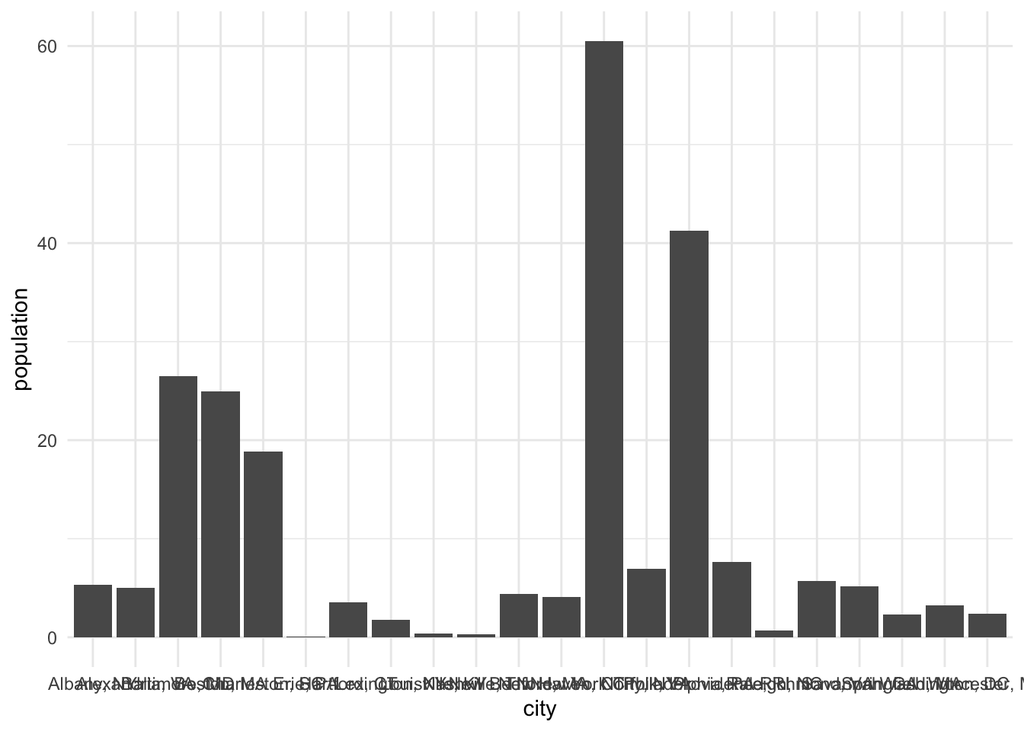

```r
us %>%
  filter(year == 1800) %>%
  filter(population > 0) %>%
  ggplot(aes(city, population)) +
    geom_col()
```

You will notice that the labels are too difficult to read because they run into one another. Modify this plot in the code block below by adding the layer `coord_flip` to switch the x- and y-axes. (Note: We cannot just directly flip the two aes values because `geom_col` always draws vertical boxes).

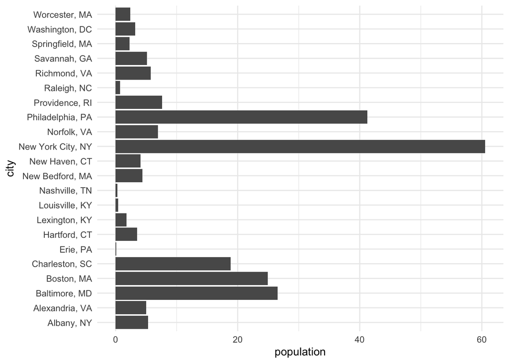

```r
us %>%
  filter(year == 1800) %>%
  filter(population > 0) %>%
  ggplot(aes(city, population)) +
    geom_col() +
    coord_flip()
```

How easy do you find this plot to read? What improvements might you want to make to it? (Don’t worry about what you can do right now; think about what would make it easier to interpret). **Answer**: I find it relatively easy to read, though it would be good to re-order the data in a more meaningful way, such as from the largest to the smallest city.

## Arranging rows

In the code below, extract the five European cities from `cities` that have the largest urban population. (Note: this will take three different verbs).

```r
cities %>%
  filter(continent == "Europe") %>%
  arrange(desc(population)) %>%
  slice(1:5)
```

```
## # A tibble: 5 x 26
##   name  country city_definition population city_pop city_area metro_pop
##   <chr> <chr>   <chr>                <dbl>    <dbl>     <dbl>     <dbl>
## 1 Ista… Turkey  Metropolitan m…      14.8     15.0       5196     NA
## 2 Mosc… Russia  Federal city         12.4     13.2       2511     NA
## 3 Paris France  Commune              10.9      2.15       105     12.2
## 4 Lond… United… Capital city          9.05     8.82      1572     14.4
## 5 Madr… Spain   Municipality          6.50     3.27       606      6.64
## # … with 19 more variables: metro_area <dbl>, urban_pop <dbl>,
## #   urban_area <dbl>, wiki <chr>, country_code2 <chr>, country_code3 <chr>,
## #   country_name_official <chr>, continent <chr>, lon <dbl>, lat <dbl>,
## #   koppen_code <chr>, koppen_main <chr>, city <chr>, num <dbl>,
## #   cost_of_living <dbl>, cost_rent <dbl>, cost_groceries <dbl>,
## #   cost_restaurant <dbl>, local_pp <dbl>
```

Which European city in our data set has the largest urban population? **Answer**: Istanbul (though, technically much of the city is actually in Asia).

## Selecting columns

Take the `cities` data set and filter only those cities in Africa and Europe. Use the select function to see just the city name and the variable `koppen_code`.

```r
cities %>%
  filter(continent %in% c("Africa", "Europe")) %>%
  select(name, koppen_code)
```

```
## # A tibble: 15 x 2
##    name             koppen_code
##    <chr>            <chr>
##  1 Cairo            BWh
##  2 Istanbul         Csa
##  3 Lagos            Aw
##  4 Kinshasa         Aw
##  5 Moscow           Dfb
##  6 Paris            Cfb
##  7 London           Cfb
##  8 Luanda           BSh
##  9 Madrid           BSk
## 10 Dar es Salaam    Aw
## 11 Khartoum         BWh
## 12 Barcelona        Cfb
## 13 Johannesburg     Cwb
## 14 Saint Petersburg Dfb
## 15 Alexandria       BWh
```

## Layering graphics

In the code below, create a data set called `cities_large_metro` by extracting the rows of `cities` that have a metro region larger than the U.N. estimate of the city’s population.

```r
cities_large_metro <- cities %>%
  filter(population < metro_pop)
```

Now, draw a scatter plot with longitude on the x-axis and latitude on the y-axis. Show all of the rows in the data set using a light grey color. Then, add points layer and a text layer (with the city names as labels) for the rows in `cities_large_metro`. Pick a bold color for the points and labels.

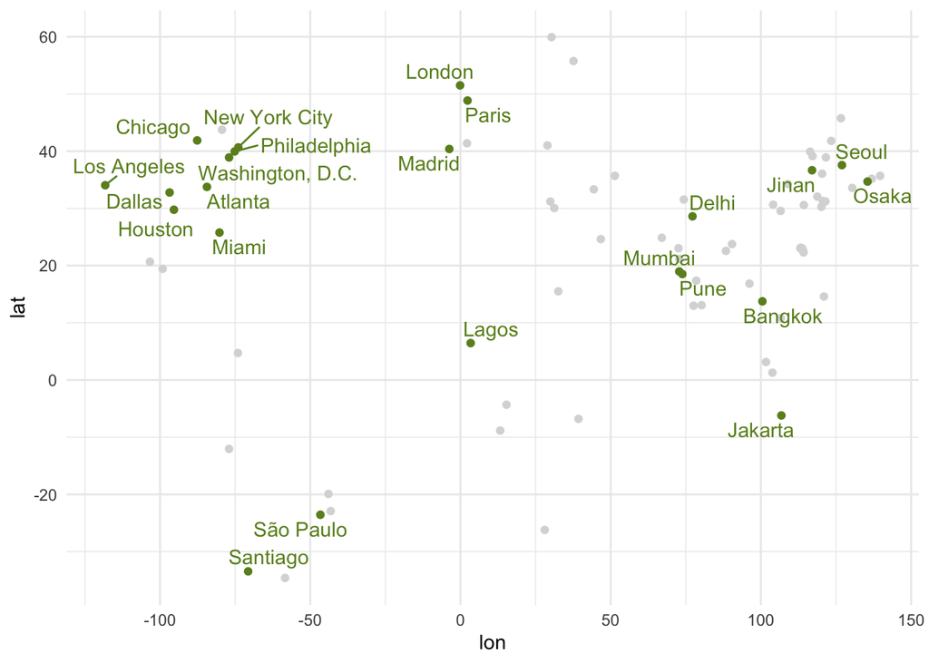

```r
cities %>%
  ggplot(aes(lon, lat)) +
    geom_point(color = "grey85") +
    geom_point(color = "olivedrab", data = cities_large_metro) +
    geom_text_repel(aes(label = name), color = "olivedrab", data = cities_large_metro)
```

Do you see any particular patterns about which cities have metropolitan regions that are larger than the city’s official U.N.-listed population? (Note: There is at least one thing that becomes apparent, but you will probably not find something that explains all of the data). **Answer**: While there are cities in all of the major continents, there is a particular concentration of cities with large metro areas in the United States.